# Deconvolution and nonnegative matrix factorization

Peter Ralph

Advanced Biological Statistics

# Visualizing expression space

## A conceptual model

Let’s build a *conceptual* model for descriptive analysis of “mixture” expression data.

**Data:** expression data from tissue samples that consist of various *mixtures* of different cell types.

**Goal:** identify shared coexpression patterns corresponding to *cell type*.

*Similar situations:* identify different developmental stages from whole-organism expression; common community structures from metagenomic data.

1. Each cell type has a typical set of *mean* expression levels.
2. Each sample is composed of a mixture of cell types, defined by the proportions that come from each type.
1. Mean expression by cell type.
2. Cell type proportions by sample.
1. $x_{kj}$ : Mean expression of gene $j$ in cell type $k$.
2. $w_{ik}$ : Proportion of sample $i$ of cell type $k$.

$Z_{ij}$ : expression level in sample $i$ of gene $j$.

$$\begin{aligned}
Z_{ij} \approx \sum_{k=1}^K w_{ik} x_{kj} .
\end{aligned}$$

# Nonnegative matrix factorization

## … aka “NMF”

We are *decomposing* $Z$ into the product of two lower-dimensional, nonnegative factors:

$$\begin{aligned}
Z_{ij} &\approx \sum_k w_{ik} x_{kj} \\
w_{ik} &\ge 0 \\
x_{kj} &\ge 0 .
\end{aligned}$$

## A simple NMF model

```
simple_nmf <- stan_model(model_code="
data {
    int N; // samples
    int L; // variables
    int K; // factors
    real Z[L,N];
}
parameters {
    matrix<lower=0>[L,K] x;
    matrix<lower=0>[K,N] w;
    real<lower=0> sigma;
}
model {
    for (j in 1:L) {
        Z[j] ~ normal(x[j] * w, sigma);
    }
}
")
```

## Relationship to PCA

PCA finds $w$ and $z$ to minimize
$$\begin{aligned}
\sum_{ij} \| Z_{ij} - \sum_k w_{ik} x_{kj} \|^2 .
\end{aligned}$$

In other words, it is the maximum-likelihood solution to
$$\begin{aligned}
Z_{ij} &\sim \Normal(\sum_k w_{ik} x_{kj}, \sigma^2) .
\end{aligned}$$
(The eigenvectors are the columns of $x$, and the eigenvectors are related to the size of $w$ and $x$.)

## PCA, in Stan

```
stan_pca <- stan_model(model_code="
data {
    int N; // samples
    int L; // variables
    int K; // factors
    real Z[L,N];
}
parameters {
    matrix[L,K] x;
    matrix[K,N] w;
    real<lower=0> sigma;
}
model {
    for (j in 1:L) {
        Z[j] ~ normal(x[j] * w, sigma);
    }
}
")
```

*(note: needs some priors to work well; see [here](https://arxiv.org/abs/1603.00788).)*

# Stochastic minute

## the Dirichlet distribution

A random set of $k$ *proportions* $0 \le P_i \le 1$ has a $\Dirichlet(\alpha_1, \ldots, \alpha_k)$ if it has probability density
$$\begin{aligned}
\frac{1}{B(\alpha)} \prod_{i=1}^k p_i^{\alpha_i}
\end{aligned}$$
over the set of possible values
$$\begin{aligned}
P_1 + \cdots + P_k = 1 .
\end{aligned}$$

1. This is useful as a prior on *proportions*.
2. The *mean* is
   $$\left( \frac{\alpha_1}{\sum_j \alpha_j}, \frac{\alpha_2}{\sum_j \alpha_j}, \cdots, \frac{\alpha_k}{\sum_j \alpha_j} \right) .$$
3. This generalizes the Beta: if $X \sim \Beta(a, b)$ then $(X, 1-X) \sim \Dirichlet(a, b)$.
4. Marginal distributions are Beta distributed: $P_i \sim \Beta(\alpha_i, \sum_{j=1}^k \alpha_j - \alpha_i)$.
5. If $X_i \sim \Gam(\text{shape}=\alpha_i)$, and
   $$\begin{aligned}
   P_i = X_i / \sum_{j=1}^k X_j
   \end{aligned}$$
   then $P \sim \Dirichlet(\alpha)$.

## “Simplex” parameters

“The $k$-simplex” is the set of *proportions*, i.e., nonnegative numbers $p$ satisfying
$$\begin{aligned}
p_1 + \cdots p_k = 1 .
\end{aligned}$$

```
parameters {
    simplex[K] p;
}
model {
    p ~ dirichlet(alpha);
}
```

## Exercise

1. Simulate 10,000 samples from the $\Dirichlet(20, 10, 3)$ distribution. (This should be a 10,000 x 3 matrix.)
2. Confirm that rows sum to 1.
3. Confirm that columns have the correct means.
4. Plot the result (the pairwise plots, or in 3D).
5. Do the same for $\alpha = (0.2, 0.1, 0.03)$.

## IN CLASS

```r
# 1. Simulate 10,000 samples from the Dirichlet(20, 10, 3)
#   distribution. (This should be a 10,000 x 3 matrix.)

alpha <- c(20, 10, 3)
P <- matrix(NA, nrow=10000, ncol=length(alpha))
for (i in 1:nrow(P)) {
    X <- rgamma(3, shape=alpha)
    P[i,] <- X / sum(X)
}

# Confirm that rows sum to 1.

stopifnot(all(
    abs(rowSums(P) - 1) < 1e-15
))

# Confirm that columns have the correct means.

true_means <- alpha / sum(alpha)
rbind(true_means, colMeans(P))
```

```
##                 [,1]      [,2]       [,3]
## true_means 0.6060606 0.3030303 0.09090909
##            0.6049487 0.3045743 0.09047700
```

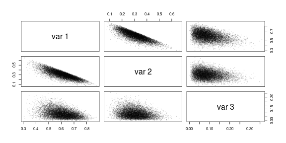

```r
# Plot the result (the pairwise plots, or in 3D).

pairs(P, pch=20, cex=0.25, col=adjustcolor("black", 0.1))
```

# Back to expression space

1. Each cell type has a typical set of *mean* expression levels.
2. Each sample is composed of a mixture of cell types, defined by the proportions that come from each type.
3. Mean expression levels differ between cell types for only some of the genes.
1. Mean expression by cell type.
2. Cell type proportions by sample.
1. $x_{kj}$ : Mean expression of gene $j$ in cell type $k$.
2. $w_{ik}$ : Proportion of sample $i$ of cell type $k$.

$Z_{ij}$ : expression in sample $i$ of gene $j$.

$$\begin{aligned}
Z_{ij} \approx \sum_{k=1}^K w_{ik} x_{kj} .
\end{aligned}$$

1. Mean expression by cell type.
2. Cell type proportions by sample.
3. Mean expression levels differ between cell types for only some of the genes.

$Z_{ij}$ : expression level in sample $i$ of gene $j$.

$$\begin{aligned}
Z_{ij} \approx \sum_{k=1}^K w_{ik} x_{kj} .
\end{aligned}$$

3. $\bar x_j$, $\eta_j$ : mean and SD of expression of gene $j$ across *all* cell types; shrink $x_{kj}$ towards $\bar x_j$.

```
data {
  int N; // # samples
  int L; // # genes
  int K; // # cell types
  int Z[N,L];
}
```

```
parameters {
  matrix<lower=0>[K,L] x;
  vector<lower=0>[N] y;
  vector<lower=0>[L] x_bar;
  simplex[K] w[N];
  real<lower=0> eta;
  vector<lower=0>[K] alpha;
}
```

```
model {
  matrix[N,L] mean_Z;
  for (i in 1:N) {
    for (j in 1:L) {
      mean_Z[i,j] = 0.0;
      for (k in 1:K) {
        mean_Z[i,j] += y[i] * w[i][k] * x[k,j];
      }
    }
    Z[i,] ~ poisson(mean_Z[i,]);
    w[i] ~ dirichlet(alpha);
  }
  for (k in 1:K)
      { x[k,] ~ normal(x_bar, eta * x_bar); }
  y ~ normal(0, 10);
  alpha ~ exponential(1);
  eta ~ normal(0, 4);
  x_bar ~ gamma(0.5, 0.5e-4);
}
```

1. $x_{kj}$ : Mean expression of gene $j$ in cell type $k$.
2. $w_{ik}$ : Proportion of sample $i$ of cell type $k$.
3. $y_{i}$ : Total sequencing depth of sample $i$.

$$\begin{aligned}
Z_{ij} \approx y_i \sum_k w_{ik} x_{kj} .
\end{aligned}$$

4. $\bar x_j$, $\eta_j$ : mean and SD of expression of gene $j$ across *all* cell types; shrink $x_{kj}$ towards $\bar x_j$.

## Testing: compiles?

```r
nmf_model <- stan_model(model_code=nmf_block)
```

## Testing: runs?

```r
sampling(nmf_model,
         data=list(N=10,
                   L=5,
                   K=2,
                   Z=matrix(rpois(50, 100), ncol=5)),
         chains=1, iter=100)
```

```
## Inference for Stan model: 64f2c322cbd474154082cded7e231b18.
## 1 chains, each with iter=100; warmup=50; thin=1;
## post-warmup draws per chain=50, total post-warmup draws=50.
##
##              mean se_mean   sd     2.5%      25%      50%      75%    97.5% n_eff Rhat
## x[1,1]      11.71    0.42 2.99     7.34     9.44    11.54    13.10    18.57    51 0.98
## x[1,2]      12.97    0.64 3.75     7.92     9.85    12.83    14.45    20.34    34 1.03
## x[1,3]      12.92    0.61 4.01     8.04    10.03    12.07    14.52    22.77    43 1.00
## x[1,4]      13.18    0.64 4.16     8.10    10.28    12.37    14.47    24.46    42 0.98
## x[1,5]      12.35    0.50 3.35     7.64     9.59    12.27    13.82    20.19    45 1.01
## x[2,1]      12.21    0.53 3.50     6.75     9.46    11.54    14.40    19.29    44 1.01
## x[2,2]      12.81    0.50 3.46     8.21    10.37    12.22    13.89    21.59    48 0.99
## x[2,3]      13.18    0.51 3.54     8.43    10.43    12.89    14.75    19.74    49 1.01
## x[2,4]      13.20    0.57 3.69     8.30    10.61    12.61    15.17    20.07    42 1.00
## x[2,5]      12.33    0.48 3.46     7.85     9.79    11.71    14.15    19.39    52 1.00
## y[1]         8.34    0.28 2.12     5.08     6.86     8.07     9.81    11.94    56 1.01
## y[2]         7.97    0.24 2.01     4.70     6.55     7.80     9.13    12.40    68 0.99
## y[3]         8.01    0.25 1.98     4.96     6.72     7.78     9.45    11.89    61 1.03
## y[4]         8.03    0.28 2.08     4.88     6.68     7.67     9.29    12.15    57 1.02
## y[5]         7.83    0.26 2.06     4.63     6.42     7.61     9.17    11.60    63 1.02
## y[6]         8.81    0.29 2.24     5.13     7.47     8.47    10.32    13.47    60 1.01
## y[7]         8.18    0.26 2.12     4.90     6.63     8.15     9.66    11.74    67 1.00
## y[8]         8.55    0.27 2.10     5.16     7.27     8.06     9.99    12.99    62 0.99
## y[9]         8.42    0.26 2.13     5.16     6.80     8.14     9.92    12.59    66 1.00
## y[10]        8.37    0.25 2.19     5.07     6.89     8.28     9.96    12.44    79 1.00
## x_bar[1]    11.97    0.39 2.94     7.72     9.41    11.57    14.06    18.05    57 1.01
## x_bar[2]    13.23    0.75 3.72     8.16    10.28    12.62    14.48    21.59    25 1.02
## x_bar[3]    13.42    0.86 5.08     7.58    10.32    12.93    14.12    26.95    35 0.99
## x_bar[4]    13.30    0.55 3.71     8.53    10.67    12.94    15.09    22.59    46 1.00
## x_bar[5]    12.11    0.48 3.27     7.61     9.47    11.74    13.52    19.75    47 1.01
## w[1,1]       0.32    0.07 0.28     0.00     0.07     0.25     0.55     0.89    16 1.06
## w[1,2]       0.68    0.07 0.28     0.11     0.45     0.75     0.93     1.00    16 1.06
## w[2,1]       0.34    0.08 0.28     0.00     0.11     0.28     0.51     0.96    12 1.00
## w[2,2]       0.66    0.08 0.28     0.04     0.49     0.72     0.89     1.00    12 1.00
## w[3,1]       0.39    0.08 0.38     0.00     0.03     0.23     0.77     1.00    21 1.03
## w[3,2]       0.61    0.08 0.38     0.00     0.23     0.77     0.97     1.00    21 1.03
## w[4,1]       0.43    0.09 0.34     0.00     0.08     0.43     0.68     1.00    16 1.03
## w[4,2]       0.57    0.09 0.34     0.00     0.32     0.57     0.92     1.00    16 1.03
## w[5,1]       0.37    0.11 0.34     0.00     0.03     0.35     0.65     0.99    10 1.10
## w[5,2]       0.63    0.11 0.34     0.01     0.35     0.65     0.97     1.00    10 1.10
## w[6,1]       0.40    0.07 0.36     0.00     0.05     0.26     0.69     1.00    28 1.02
## w[6,2]       0.60    0.07 0.36     0.00     0.31     0.74     0.95     1.00    28 1.02
## w[7,1]       0.35    0.10 0.31     0.00     0.06     0.25     0.63     0.86    11 1.01
## w[7,2]       0.65    0.10 0.31     0.14     0.37     0.75     0.94     1.00    11 1.01
## w[8,1]       0.38    0.09 0.31     0.00     0.08     0.42     0.62     0.98    11 1.01
## w[8,2]       0.62    0.09 0.31     0.02     0.38     0.58     0.92     1.00    11 1.01
## w[9,1]       0.40    0.06 0.36     0.00     0.04     0.29     0.76     0.96    40 1.04
## w[9,2]       0.60    0.06 0.36     0.04     0.24     0.71     0.96     1.00    40 1.04
## w[10,1]      0.37    0.11 0.34     0.00     0.03     0.30     0.63     0.96    10 1.12
## w[10,2]      0.63    0.11 0.34     0.04     0.37     0.70     0.97     1.00    10 1.12
## eta          0.11    0.02 0.06     0.04     0.06     0.09     0.17     0.22     8 1.06
## alpha[1]     1.09    0.28 1.08     0.08     0.33     0.72     1.52     3.93    15 1.02
## alpha[2]     1.72    0.34 1.35     0.18     0.74     1.24     2.62     4.42    16 0.99
## lp__     17637.53    3.40 9.23 17617.23 17633.66 17637.51 17643.56 17653.66     7 0.99
##
## Samples were drawn using NUTS(diag_e) at Thu Feb 24 15:16:48 2022.
## For each parameter, n_eff is a crude measure of effective sample size,
## and Rhat is the potential scale reduction factor on split chains (at
## convergence, Rhat=1).
```